# Association rules

Movie recommender systems

Parand Alizadeh

2018-07-13 22:30:39

> با استفاده از داده نظرهای فیلم به سوالات زیر پاسخ دهید.

۱. آماره های زیر را بیابید. الف. محبوب ترین فیلم کدام است؟ ب. بیشترین نظرات درباره چه فیلمی داده شده است؟ پ. منفورترین فیلم کدام است؟ ت. تعداد فیلم های ساخته شده در هر سال ث. در هر سالی مردم به چه ژانری علاقه مند بوده اند.

قسمت الف

```
##  [1] "Satan's Tango (Sátántangó) (1994)"
##  [2] "Shadows of Forgotten Ancestors (1964)"
##  [3] "Fighting Elegy (Kenka erejii) (1966)"
##  [4] "Sun Alley (Sonnenallee) (1999)"
##  [5] "Blue Light, The (Das Blaue Licht) (1932)"
##  [6] "More (1998)"
##  [7] "Who's Singin' Over There? (a.k.a. Who Sings Over There) (Ko to tamo peva) (1980)"
##  [8] "Human Condition II, The (Ningen no joken II) (1959)"
##  [9] "Human Condition III, The (Ningen no joken III) (1961)"
## [10] "Constantine's Sword (2007)"
```

قسمت ب

```
##  [1] "Pulp Fiction (1994)"
##  [2] "Forrest Gump (1994)"
##  [3] "Silence of the Lambs, The (1991)"
##  [4] "Jurassic Park (1993)"
##  [5] "Shawshank Redemption, The (1994)"
##  [6] "Braveheart (1995)"
##  [7] "Fugitive, The (1993)"
##  [8] "Terminator 2: Judgment Day (1991)"
##  [9] "Star Wars: Episode IV - A New Hope (a.k.a. Star Wars) (1977)"
## [10] "Apollo 13 (1995)"
```

قسمت پ

```
##  [1] "Dog Run (1996)"
##  [2] "Stacy's Knights (1982)"
##  [3] "From Justin to Kelly (2003)"
##  [4] "Disaster Movie (2008)"
##  [5] "Hip Hop Witch, Da (2000)"
##  [6] "SuperBabies: Baby Geniuses 2 (2004)"
##  [7] "War of the Worlds 2: The Next Wave (2008)"
##  [8] "Accused (Anklaget) (2005)"
##  [9] "Hi-Line, The (1999)"
## [10] "Besotted (2001)"
```

قسمت ت

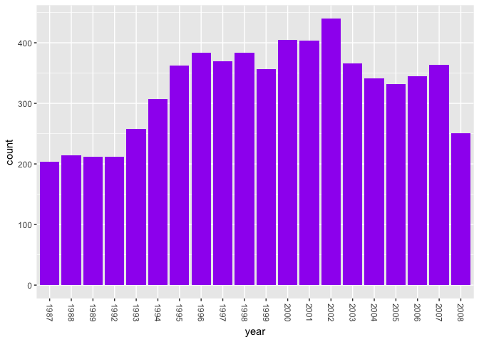

قسمت ث

```
## # A tibble: 17 x 2
## # Groups:   year [15]
##    year  genre
##    <chr> <chr>
##  1 1995  Horror
##  2 1995  Mystery
##  3 1995  Thriller
##  4 1996  War
##  5 1997  Film-Noir
##  6 1998  Film-Noir
##  7 1999  Film-Noir
##  8 2000  Film-Noir
##  9 2001  Film-Noir
## 10 2002  Film-Noir
## 11 2003  Film-Noir
## 12 2004  Film-Noir
## 13 2005  Film-Noir
## 14 2006  Film-Noir
## 15 2007  (no genres listed)
## 16 2008  IMAX
## 17 2009  IMAX
```

۲. ژانر فیلم ها را استخراج نمایید. سپس آماره های زیر را استخراج نمایید. الف. نمودار ستونی تعداد فیلم های هر ژانر ب. نمودار همبستگی ژانرها پ. متوسط امتیاز به هر ژانر ت. دوران طلایی فیلم سازی

قسمت الف

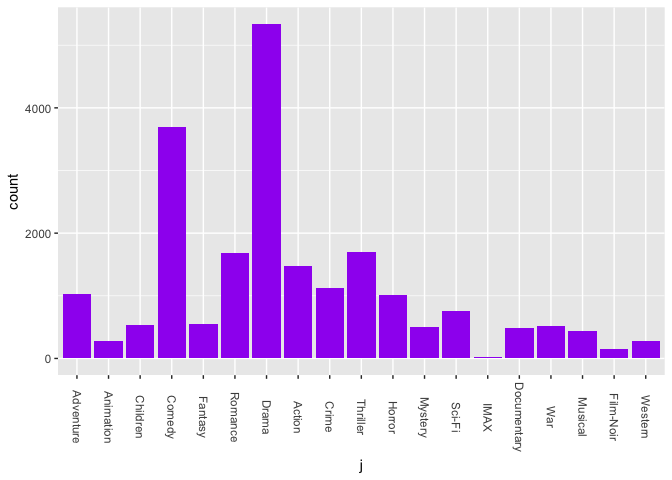

قسمت ب

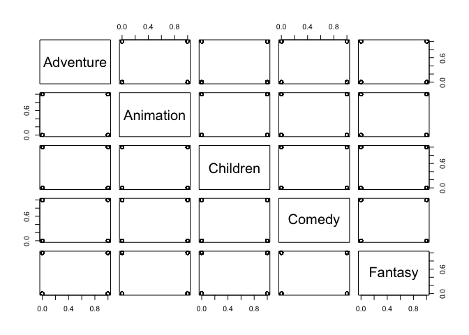

قسمت پ

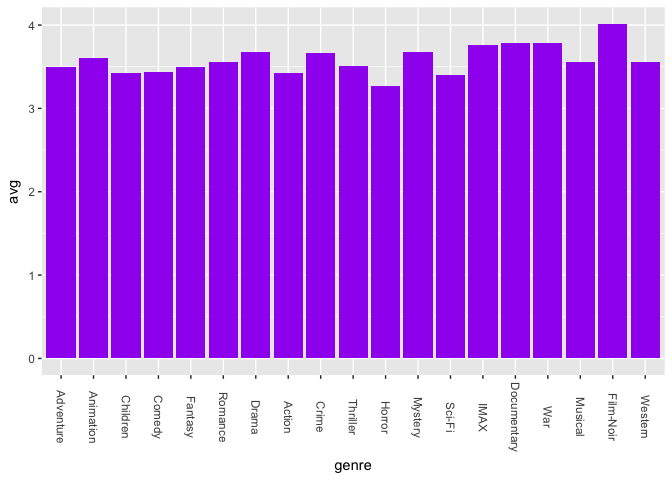

قسمت ت

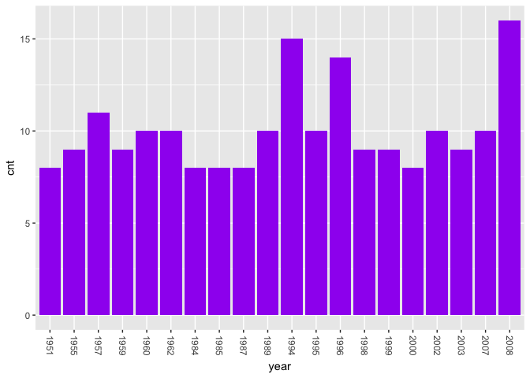

***

۳. نمودار ابر لغات را بر حسب کلمات عنوان فیلم ها رسم نمایید.

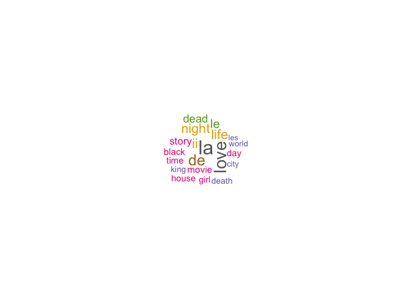

۴. با استفاده از قوانین همبستگی یک توصیه گر برای فیلم ها بسازید. شبیه ترین فیلم ها به لیست زیر را پیدا کنید.

- Castle in the Sky (1986)
- Cast Away (2000)
- No Country for Old Men (2007)
- Memento (2000)

```
## Apriori
##
## Parameter specification:
##  confidence minval smax arem  aval originalSupport maxtime support minlen
##        0.25    0.1    1 none FALSE            TRUE       5   0.001      2
##  maxlen target   ext
##      10  rules FALSE
##
## Algorithmic control:
##  filter tree heap memopt load sort verbose
##     0.1 TRUE TRUE  FALSE TRUE    2    TRUE
##
## Absolute minimum support count: 69
##
## set item appearances ...[4 item(s)] done [0.00s].
## set transactions ...[10597 item(s), 69863 transaction(s)] done [1.16s].
## sorting and recoding items ... [5891 item(s)] done [0.23s].
## creating transaction tree ... done [0.06s].
## checking subsets of size 1 2 3 4 5 done [3.60s].
## writing ... [5584 rule(s)] done [0.02s].
## creating S4 object  ... done [0.04s].
```

```
##  [1] {Iron Man (2008)}
##  [2] {Children of Men (2006)}
##  [3] {Dark Knight, The (2008)}
##  [4] {Prestige, The (2006)}
##  [5] {Pan's Labyrinth (El Laberinto del fauno) (2006)}
##  [6] {Little Miss Sunshine (2006)}
##  [7] {Princess Mononoke (Mononoke-hime) (1997)}
##  [8] {Departed, The (2006)}
##  [9] {Spirited Away (Sen to Chihiro no kamikakushi) (2001)}
## [10] {Casino Royale (2006)}
## 728 Levels: {12 Angry Men (1957)} ... {Zoolander (2001)}
```

۵. تمرین سخت: در گیت هاب برای خود اکانت درست کنید. همه تمرین های خود را آنجا بارگذاری کنید! و لینک آن را ارسال نمایید.

https://github.com/praal/data_analysis_course

۶. پنج انتقاد از درس و نحوه تدریس را بیان کنید.

شاید بهتر بود از نظر علمی و آماری دقیق تر مباحث را بررسی کنیم.

تمرین های تئوری ریاضی باعث بهبود یادگیری میشد.

تمرین ها با اینکه جالب بودند اما شاید حجم زیادی از آنها تکراری میشد و جنبه آموزشی نداشت و در تمرین های قبلی مشابه آنها انجام شده بود.

حجم و تعداد تمرین ها زیاد بود.

امتحان درس شاید خیلی مشابه کاری که در طول ترم انجام دادیم نبود.

۷. پنج پیشنهاد برای بهتر شدن درس بیان کنید.

مباحث ریاضی بیشتری پوشش داده شود.

تئوری عمیق تر بررسی شود.

امتحان عملی.

مباحث مربوط به ماشین لرنینگ بیشتری پوشش داده شود.

مثال های واقعی از تحلیل داده و نتیجه گیری بر اساس آن آورده شود.

۸. سه موضوع آماری جدید برای جایگزینی در سرفصل ها پیشنهاد دهید.

تخمین - سپملینگ - داده های کتگوریکال و تکنیک های مربوط به آنها

۹. سه داده جالب برای کار در کلاس پیشنهاد دهید.

داده های شبکه های اجتماعی که در سایت استنفورد موجود است.

http://snap.stanford.edu

داده تاکسی های نیویورک و مسیریابی

داده های سایت های مثل استک اور فلو

۱۰. چهار نکته مهمی که در کلاس یاد گرفتید را بیان کنید.

آشنا شدن و فهمیدن داده از دانستن تکنیک ها مهم تر است

تصویر سازی داده قبل از اعمال هر تکنیکی به تحلیل بهتر کمک میکند.

با تست های فرض و تئوری های پشت آنها آشنا شدم.

تحلیل داده ها میتواند گمراه کننده باشد و میتوان آن را طوری استفاده کرد که به نفع موضوعی که میخواهیم باشد.